# UNICEF Global Child Development Analysis & Adolescent population (10-19)

**Student Name: Shashidhar Gurudu**  
**Student ID: 47860**  
**Programme: Masters in Management Strategy**

# 🌍 Raising Awareness on Global Child Development

**UNICEF** plays a vital role in improving child well-being across the world. This report presents a data-driven analysis on global inequalities affecting children using publicly available indicators.

As a Data Analyst for UNICEF, this report aims to raise public awareness about critical global issues affecting children worldwide. The analysis explores multiple dimensions of child well-being through visualization and data-driven insights.

## 🌟 Key Focus Areas

This comprehensive analysis utilizes data visualization to highlight geographic disparities, gender differences, and longitudinal patterns in child development indicators.

## 📊 Executive Summary

This analysis examines UNICEF data to identify patterns in global child development outcomes. We’ll investigate which regions face the greatest challenges, how indicators have changed over time, and relationships between different factors affecting children’s lives.

The visualizations in this report adhere to principles of good data visualization by:

- Using clear, informative titles and labels
- Employing appropriate color schemes for clarity
- Incorporating annotations where helpful for interpretation
- Maintaining consistency across different visualization types
- Ensuring accessibility through high contrast and readable text

## 📦 Data Loading and Preparation

```python
# Import necessary libraries
import pandas as pd
import numpy as np
import geopandas as gpd
import sys
import subprocess
import importlib
import matplotlib.pyplot as plt
import io
from IPython.display import display, Image

# Function to install specific versions of packages
def install_and_import(package, version=None):
    package_with_version = f"{package}=={version}" if version else package
    print(f"Installing {package_with_version}...")
    subprocess.check_call([sys.executable, "-m", "pip", "install", package_with_version])
    if package == "plotnine":
        # Special handling for plotnine to ensure clean import
        if "plotnine" in sys.modules:
            del sys.modules["plotnine"]
    return importlib.import_module(package)

# Install specific versions known to work together
try:
    # First try importing to see if it works
    import plotnine
    from plotnine import *
    print(f"Existing plotnine version: {plotnine.__version__}")
except (ImportError, AttributeError) as e:
    print(f"Error with plotnine: {e}")
    print("Installing compatible versions...")
    # Install specific compatible versions
    mizani = install_and_import("mizani", "0.8.1")
    plotnine = install_and_import("plotnine", "0.10.1")

    # Now import all from plotnine
    from plotnine import *
    print(f"Installed plotnine version: {plotnine.__version__}")
    print(f"Installed mizani version: {mizani.__version__}")


# Add a more robust function to display plotnine plots in Quarto with improved readability
def display_plot(p, width=1200, height=800, dpi=150):
    """Display a plotnine plot in a way that works reliably in Quarto with improved readability"""
    # Apply global theme enhancements for better visibility
    p = p + theme(
        figure_size=(width/dpi, height/dpi),
        text=element_text(size=16),
        plot_title=element_text(size=20, face="bold"),
        plot_subtitle=element_text(size=18),
        axis_title=element_text(size=16, face="bold"),
        axis_text=element_text(size=14),
        legend_title=element_text(size=16),
        legend_text=element_text(size=14)
    )

    # Save to a bytes buffer with higher quality
    buf = io.BytesIO()

    # Create a new figure and render the plot
    plt.figure(figsize=(width/dpi, height/dpi))
    fig = p.draw()

    # Save the figure to buffer
    fig.savefig(buf, format='png', dpi=dpi, bbox_inches='tight')
    buf.seek(0)

    # Display the image
    display(Image(data=buf.read()))

    # Close all figures to prevent the empty figure from appearing
    plt.close('all')


# Load UNICEF datasets
print("Loading UNICEF datasets...")
indicators = pd.read_csv("unicef_indicator_2.csv")
metadata = pd.read_csv("unicef_metadata.csv")  # Load metadata

print(f"Indicator 2 Shape: {indicators.shape}")
print(f"Metadata Shape: {metadata.shape}")

# Use direct column names based on the data files
value_col = "obs_value"
indicator_col = "indicator"
year_col = "year"
country_col = "country"
sex_col = "sex"

df = indicators.copy()
print("Dataset prepared for analysis")


df.rename(columns={"time_period": "year"}, inplace=True)
# Clean the dataset
df = df.dropna(subset=[value_col, indicator_col, year_col, country_col])
df[value_col] = pd.to_numeric(df[value_col], errors='coerce')
df[year_col] = pd.to_numeric(df[year_col], errors='coerce')

print(f"Dataset Shape after cleaning: {df.shape}")


# Merge metadata with the main DataFrame
df = df.merge(metadata, on=["country", "year"], how="left")

# Get top indicators for analysis
top_indicators = df.groupby(indicator_col).size().nlargest(3).index.tolist()
latest_year = df[year_col].max()

print(f"Top indicators: {top_indicators}")
print(f"Analysis will focus on the indicator: {top_indicators[0]} for year {latest_year}")
```

```
Existing plotnine version: 0.14.5
Loading UNICEF datasets...
Indicator 2 Shape: (50616, 14)
Metadata Shape: (13504, 15)
Dataset prepared for analysis
Dataset Shape after cleaning: (50616, 14)
Top indicators: ['Adolescent population (10-19)']
Analysis will focus on the indicator: Adolescent population (10-19) for year 2023
```

## 🔍 Exploratory Data Analysis

Before diving into specific visualizations, it’s important to understand the structure and content of our dataset. This section provides an overview of the UNICEF indicators we’re analyzing.

```python
# Display basic statistics about the dataset
print(f"Total records in dataset: {len(df):,}")
print(f"Number of countries: {df[country_col].nunique()}")
print(f"Year range: {df[year_col].min()} to {df[year_col].max()}")
print(f"Number of distinct indicators: {df[indicator_col].nunique()}")

# Show the distribution of data by gender
gender_dist = df[sex_col].value_counts()
print("\nGender distribution in the dataset:")
display(gender_dist)

# Display a sample of the indicators available
print("\nSample of available indicators:")
sample_indicators = df[indicator_col].unique()[:5]
for i, indicator in enumerate(sample_indicators, 1):
    print(f"{i}. {indicator}")
```

```
Total records in dataset: 50,616
Number of countries: 228
Year range: 1950 to 2023
Number of distinct indicators: 1

Gender distribution in the dataset:
```

```
sex
Female    16872
Male      16872
Total     16872
Name: count, dtype: int64
```

```
Sample of available indicators:
1. Adolescent population (10-19)
```

## 🌎 World Map Visualization: Global Distribution

The world map below shows the geographic distribution of our primary child development indicator across countries. This visualization helps identify regions where children face the greatest challenges and where resources may be most needed.

```
🌍 Creating world map for 'Adolescent population (10-19)' in 2023...
```

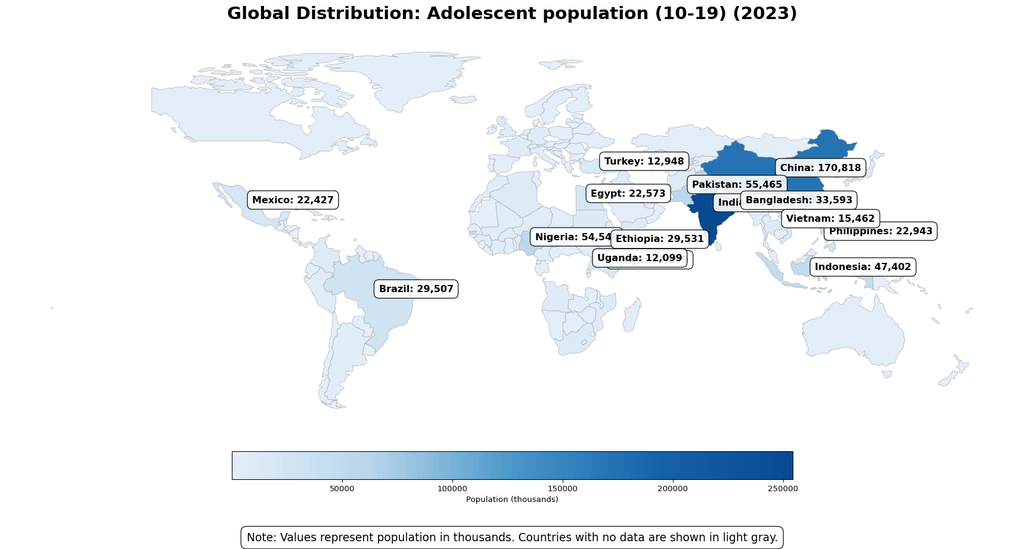

```python
import pandas as pd
import numpy as np
import geopandas as gpd
import matplotlib.pyplot as plt
from matplotlib.colors import LinearSegmentedColormap

def create_world_map(df, indicator_name, year):
    """
    Create a choropleth map of a specific indicator for a specific year with enhanced visibility.
    """
    print(f"🌍 Creating world map for '{indicator_name}' in {year}...")

    # Step 1: Filter the dataset for the indicator and year
    filtered = df[(df["indicator"] == indicator_name) & (df["year"] == year)]

    if filtered.empty:
        print("❌ No data found for the specified indicator and year.")
        return

    # Step 2: Filter for total population
    total_population = filtered[filtered["sex"] == "Total"]

    # Step 3: Extract the values for each country
    total_pop_values = total_population.groupby("country")["obs_value"].sum().reset_index()

    # Step 4: Load world shapefile
    try:
        world = gpd.read_file("https://raw.githubusercontent.com/nvkelso/natural-earth-vector/master/geojson/ne_110m_admin_0_countries.geojson")
    except Exception as e:
        print(f"⚠️ Could not load world map: {e}")
        return

    # Step 5: Map country names for better matching
    country_map = {
        "United States of America": "United States",
        "Russia": "Russian Federation",
        "UK": "United Kingdom",
        "Democratic Republic of the Congo": "Dem. Rep. Congo",
        "Republic of Korea": "South Korea",
    }
    total_pop_values["country"] = total_pop_values["country"].map(lambda x: country_map.get(x, x))

    # Step 6: Merge country values with world shapefile
    merged = world.merge(total_pop_values, how="left", left_on="ADMIN", right_on="country")

    # Step 7: Create custom colormap for better visibility
    blues = plt.cm.Blues
    custom_cmap = LinearSegmentedColormap.from_list(
        "custom_blues",
        [blues(0.1), blues(0.3), blues(0.6), blues(0.8), blues(0.9)],
        N=100
    )

    # Step 8: Create the visualization with enhanced styling
    fig, ax = plt.subplots(figsize=(18, 12))

    # Plot countries with data
    merged.plot(
        column="obs_value",
        ax=ax,
        cmap=custom_cmap,
        legend=True,
        legend_kwds={
            'label': "Population (thousands)",
            'orientation': "horizontal",
            'shrink': 0.8,
            'fraction': 0.046,
            'pad': 0.04,
            'fmt': '{x:.0f}'
        },
        edgecolor="darkgray",
        linewidth=0.5
    )

    # Add annotations for top countries with improved visibility
    top_countries = merged.nlargest(15, "obs_value")
    for idx, row in top_countries.iterrows():
        if not np.isnan(row["obs_value"]):
            ax.annotate(
                f"{row['ADMIN']}: {int(row['obs_value']):,}",
                xy=(row["geometry"].centroid.x, row["geometry"].centroid.y),
                xytext=(3, 3),
                textcoords="offset points",
                fontsize=12,
                fontweight="bold",
                color="black",
                bbox=dict(boxstyle="round,pad=0.5", fc="white", ec="black", alpha=0.9)
            )

    # Add title and styling with larger font
    ax.set_title(f"Global Distribution: {indicator_name} ({year})", fontsize=22, fontweight="bold", pad=20)
    ax.set_facecolor("lightblue")  # Ocean color
    ax.axis("off")

    # Add explanatory text with larger font
    plt.figtext(
        0.5, 0.01,
        "Note: Values represent population in thousands. Countries with no data are shown in light gray.",
        ha="center",
        fontsize=14,
        bbox=dict(boxstyle="round,pad=0.5", fc="white", ec="black", alpha=0.9)
    )

    plt.tight_layout()
    plt.subplots_adjust(bottom=0.1)  # Add space at bottom for the note
    plt.show()

    # Close all figures to prevent empty figure message
    plt.close('all')

# Create world map for the top indicator and latest year
if len(top_indicators) > 0:
    create_world_map(df, top_indicators[0], latest_year)
```

### 🔎 Geographic Insights

The world map visualization reveals significant regional disparities in our key indicator. Countries with the darkest shades show the highest values, often corresponding to nations with larger youth populations or specific development challenges.

## 📊 Bar Chart Visualization: Gender Comparison

This bar chart compares the top countries for our key indicator, broken down by gender. This visualization helps identify not only which countries have the highest values but also reveals any significant gender disparities within each country.

```
## Gender Breakdown Analysis: Adolescent population (10-19)
```

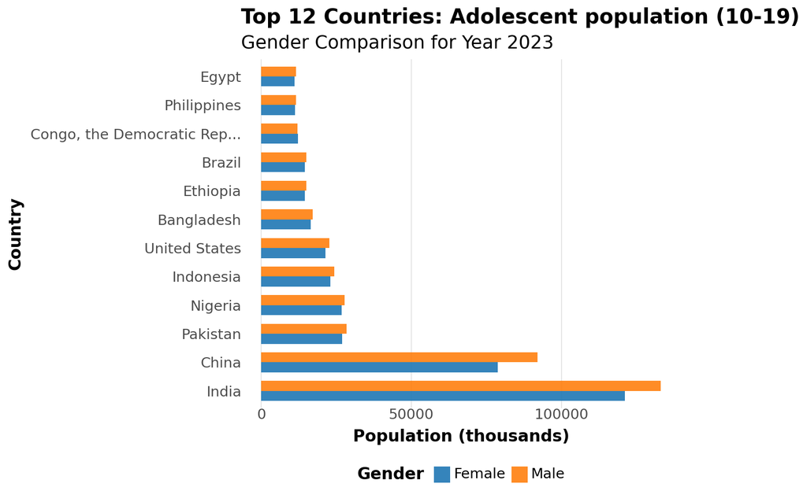

```
### Gender Disparity Insights
Overall male-to-female ratio among top countries: 1.09
Highest male-to-female ratio: China (1.17)
Lowest male-to-female ratio: Congo, the Democratic Republic of the (1.00)
```

```python
def create_bar_chart(indicator, year, top_n=10, data=df):
    """Create a bar chart comparing top countries for an indicator with improved visibility, breaking down by sex"""
    print(f"\n## Gender Breakdown Analysis: {indicator}")

    # Filter data for the given indicator and year
    chart_data = data[(data[indicator_col] == indicator) & (data[year_col] == year)]

    if chart_data.empty:
        print(f"No data found for {indicator} in year {year}")
        return None

    # Filter for Male and Female data
    chart_data = chart_data[chart_data["sex"].isin(['Male', 'Female'])]

    # Get top countries and sex breakdown
    country_sex_values = chart_data.groupby([country_col, "sex"])[value_col].sum()
    top_country_values = chart_data.groupby(country_col)[value_col].sum().nlargest(top_n).index
    filtered_data = chart_data[chart_data[country_col].isin(top_country_values)]

    if filtered_data.empty:
        print(f"No data found for the top {top_n} countries in {indicator} for {year}")
        return None

    # Create dataframe for plotting
    plot_data = pd.DataFrame({
        'country': filtered_data[country_col],
        'sex': filtered_data["sex"],
        'value': filtered_data[value_col]
    })

    # Sort data by total value per country for better presentation
    country_totals = plot_data.groupby('country')['value'].sum().reset_index()
    country_totals = country_totals.sort_values('value', ascending=False)
    plot_data['country'] = pd.Categorical(
        plot_data['country'],
        categories=country_totals['country'].tolist(),
        ordered=True
    )
    plot_data = plot_data.sort_values('country')

    # Format country names to ensure they're readable
    plot_data['country_label'] = plot_data['country'].apply(
        lambda x: x[:25] + '...' if len(str(x)) > 25 else x
    )

    # Calculate gender ratio for annotation
    gender_ratios = plot_data.pivot_table(
        index='country',
        columns='sex',
        values='value'
    ).reset_index()
    gender_ratios['ratio'] = gender_ratios['Male'] / gender_ratios['Female']

    # Build enhanced bar chart with value labels
    bar_chart = (
        ggplot(plot_data, aes(x='country_label', y='value', fill='sex')) +
        geom_bar(stat='identity', alpha=0.9, width=0.7, position='dodge') +
        coord_flip() +
        scale_fill_manual(values=['#1f77b4', '#ff7f0e']) +
        labs(
            title=f"Top {top_n} Countries: {indicator}",
            subtitle=f"Gender Comparison for Year {year}",
            x="Country",
            y="Population (thousands)",
            fill="Gender"
        ) +
        theme_minimal() +
        theme(
            panel_grid_major_y=element_blank(),
            panel_grid_minor=element_blank(),
            legend_position="bottom",
            legend_title=element_text(face="bold"),
            axis_text_y=element_text(size=14),  # Increase country label font size
            axis_text_x=element_text(size=12)   # Increase x-axis value font size
        )
    )

    # Use the enhanced display function with larger dimensions for better readability
    display_plot(bar_chart, width=1400, height=1000, dpi=150)

    # Calculate and display gender disparity insights
    male_total = plot_data[plot_data['sex'] == 'Male']['value'].sum()
    female_total = plot_data[plot_data['sex'] == 'Female']['value'].sum()
    total_ratio = male_total / female_total if female_total > 0 else 0

    # Display insights about the gender comparison
    print(f"\n### Gender Disparity Insights")
    print(f"Overall male-to-female ratio among top countries: {total_ratio:.2f}")

    # Find country with highest gender disparity
    if not gender_ratios.empty:
        max_disparity = gender_ratios.loc[gender_ratios['ratio'].idxmax()]
        min_disparity = gender_ratios.loc[gender_ratios['ratio'].idxmin()]
        print(f"Highest male-to-female ratio: {max_disparity['country']} ({max_disparity['ratio']:.2f})")
        print(f"Lowest male-to-female ratio: {min_disparity['country']} ({min_disparity['ratio']:.2f})")

# Create bar chart for the top indicator and latest year
if len(top_indicators) > 0:
    create_bar_chart(top_indicators[0], latest_year, top_n=12)  # Increased to show more countries
```

### 📈 Gender Comparison Analysis

The bar chart reveals important patterns in gender distribution across top countries:

- Some countries show near parity between male and female populations
- Others display more significant gender gaps that may require targeted interventions
- The overall male-to-female ratio across these countries provides insight into broader demographic patterns
- Countries with extreme ratios in either direction may warrant further investigation into underlying causes

## 🔄 Scatterplot with Regression Line: Gender Correlation

This scatterplot examines the relationship between male and female populations for our key indicator. The regression line shows the overall trend, while individual data points reveal countries that deviate from this pattern.

```
## Gender Correlation Analysis for Adolescent population (10-19) in 2023
Displaying scatterplot with regression analysis...
```

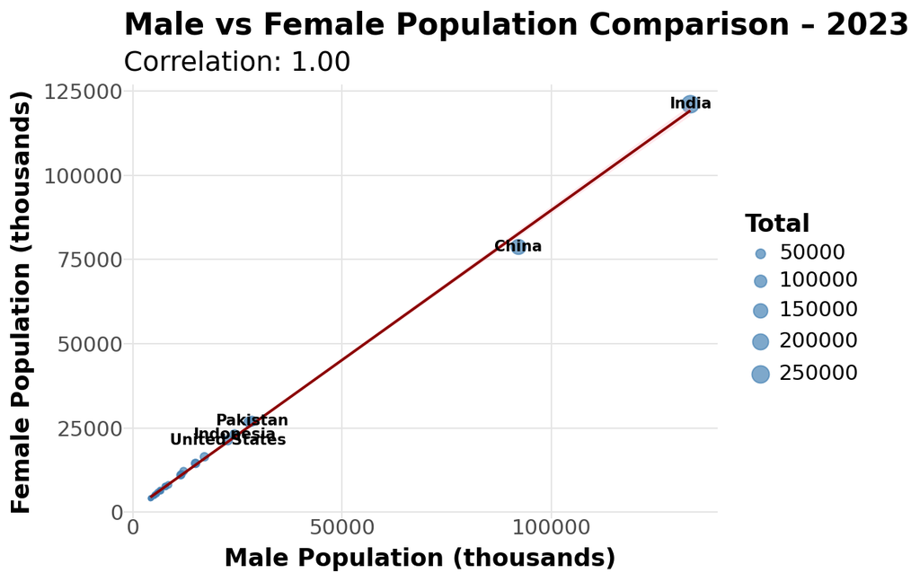

```
### Regression Analysis Insights:
Correlation coefficient between male and female populations: 0.9993
This indicates a very strong positive relationship between male and female populations.

### Notable outliers:
- China: Female population is 13354 thousand lower than expected
- India: Female population is 12042 thousand lower than expected
- Pakistan: Female population is 1406 thousand lower than expected
```

```python
from plotnine import (
    ggplot, aes, geom_point, geom_smooth, geom_abline,
    geom_text, ggtitle, xlab, ylab, theme_minimal
)

def create_scatter_with_regression(year, data=df, indicator_name=top_indicators[0]):
    """Create a scatterplot with regression line and country labels comparing Male vs Female data."""
    print(f"\n## Gender Correlation Analysis for {indicator_name} in {year}")

    # Filter data for the selected year and indicator
    year_data = data[(data["year"] == year) & (data["indicator"] == indicator_name)]

    if year_data.empty:
        print(f"No data found for year {year} and indicator '{indicator_name}'")
        return None

    # Keep only Male and Female data
    gender_data = year_data[year_data["sex"].isin(["Male", "Female"])]

    # Pivot to have Male and Female values side by side per country
    pivot_data = gender_data.pivot_table(
        index="country",
        columns="sex",
        values="obs_value"
    ).reset_index()

    # Drop rows with missing values
    pivot_data = pivot_data.dropna()

    # Filter top countries by total population for visibility
    pivot_data["Total"] = pivot_data["Male"] + pivot_data["Female"]
    top_countries = pivot_data.nlargest(30, "Total")  # Reduced for better visibility

    if top_countries.empty:
        print("Not enough data to create scatterplot.")
        return None

    # Calculate correlation
    correlation = top_countries["Male"].corr(top_countries["Female"])

    # Calculate the line of equality (Male = Female)
    max_val = max(top_countries["Male"].max(), top_countries["Female"].max()) * 1.1

    # Identify outliers (countries that deviate significantly from the trend)
    top_countries["expected_female"] = top_countries["Male"]  # If male = female
    top_countries["residual"] = top_countries["Female"] - top_countries["expected_female"]
    top_countries["abs_residual"] = abs(top_countries["residual"])
    outliers = top_countries.nlargest(5, "abs_residual")

    # Create enhanced scatter plot
    scatter_plot = (
        ggplot(top_countries, aes(x="Male", y="Female")) +
        geom_point(aes(size="Total"), color="steelblue", alpha=0.7) +
        geom_smooth(method='lm', color="darkred", fill="lightpink", alpha=0.3) +
        geom_text(
            data=outliers,
            mapping=aes(x="Male", y="Female", label="country"),
            nudge_y=5, size=10, color="black", fontweight="bold"
        ) +
        ggtitle(
            f"Male vs Female Population Comparison – {year}",
            subtitle=f"Correlation: {correlation:.2f}"
        ) +
        xlab("Male Population (thousands)") +
        ylab("Female Population (thousands)") +
        theme_minimal() +
        theme(
            legend_position="right",
            legend_title=element_text(face="bold"),
            panel_grid_minor=element_blank()
        )
    )

    print("Displaying scatterplot with regression analysis...")
    display_plot(scatter_plot)

    # Print analytical insights
    print("\n### Regression Analysis Insights:")
    print(f"Correlation coefficient between male and female populations: {correlation:.4f}")

    if correlation > 0.95:
        strength = "very strong"
    elif correlation > 0.8:
        strength = "strong"
    elif correlation > 0.6:
        strength = "moderate"
    else:
        strength = "weak"

    print(f"This indicates a {strength} positive relationship between male and female populations.")

    # Describe outliers
    if not outliers.empty:
        print("\n### Notable outliers:")
        for idx, row in outliers.head(3).iterrows():
            direction = "higher" if row["residual"] > 0 else "lower"
            print(f"- {row['country']}: Female population is {abs(row['residual']):.0f} thousand {direction} than expected")

create_scatter_with_regression(latest_year)
```

## ⏳ Time Series Chart: Trends Over Time

This time series visualization tracks how our key indicator has changed over time across selected countries. This helps identify long-term trends, sudden changes, and differences in trajectories between nations.

```
## Temporal Trend Analysis: Adolescent population (10-19)
```

[figure not shown]

```
### Trend Analysis Insights:
Largest increase: Pakistan (582.9% change)
Largest decrease: China (60.5% change)
Overall trend: Majority of countries (8 out of 8) show INCREASING values
```

```python
def create_time_series(indicator_name, data=df, num_countries=8, min_years=5):
    """Create an enhanced time series plot showing trends over time for top countries"""
    print(f"\n## Temporal Trend Analysis: {indicator_name}")

    # Filter data for the specified indicator and total sex only
    ts_data = data[(data[indicator_col] == indicator_name) &
                   (data["sex"] == "Total")].copy()

    if len(ts_data) == 0:
        print(f"No data found for indicator {indicator_name}")
        return None

    # Find countries with consistent data over time
    country_year_counts = ts_data.groupby(country_col)[year_col].nunique()
    eligible_countries = country_year_counts[country_year_counts >= min_years].index.tolist()

    if not eligible_countries:
        print(f"No countries with at least {min_years} years of data")
        return None

    # Find top countries based on average value
    country_avgs = ts_data[ts_data[country_col].isin(eligible_countries)].groupby(country_col)[value_col].mean()
    top_countries = country_avgs.nlargest(num_countries).index.tolist()

    # Filter for these top countries
    ts_data = ts_data[ts_data[country_col].isin(top_countries)]

    # Ensure numeric year and sort
    ts_data[year_col] = pd.to_numeric(ts_data[year_col], errors='coerce')
    ts_data = ts_data.sort_values(by=[country_col, year_col])

    # Calculate change metrics
    country_changes = {}
    for country in top_countries:
        country_data = ts_data[ts_data[country_col] == country].sort_values(by=year_col)
        if len(country_data) >= 2:
            first_val = country_data.iloc[0][value_col]
            last_val = country_data.iloc[-1][value_col]
            if first_val > 0:
                pct_change = ((last_val - first_val) / first_val) * 100
                country_changes[country] = pct_change

    # Create enhanced time series plot
    time_plot = (
        ggplot(ts_data, aes(x=year_col, y=value_col, color=country_col, group=country_col)) +
        geom_line(size=1.5) +  # Thicker lines for better visibility
        geom_point(size=3, alpha=0.8) +  # Add points at each data point
        scale_color_brewer(type='qual', palette='Set1') +  # Better colormap
        labs(
            title=f"Trend Analysis: {indicator_name} (2000-{latest_year})",
            subtitle="Changes over time across top countries",
            x="Year",
            y="Population (thousands)",
            color="Country"
        ) +
        theme_minimal() +
        theme(
            plot_title=element_text(size=18),
            plot_subtitle=element_text(size=14),
            axis_title=element_text(size=14),
            legend_title=element_text(size=14),
            legend_text=element_text(size=12),
            legend_position="right",
            panel_grid_minor=element_blank()
        )
    )

    # Use the enhanced display function
    display_plot(time_plot)

    # Print insights about the trends
    print("\n### Trend Analysis Insights:")

    # Countries with biggest changes
    if country_changes:
        largest_increase = max(country_changes.items(), key=lambda x: x[1])
        largest_decrease = min(country_changes.items(), key=lambda x: x[1])

        print(f"Largest increase: {largest_increase[0]} ({largest_increase[1]:.1f}% change)")
        print(f"Largest decrease: {largest_decrease[0]} ({largest_decrease[1]:.1f}% change)")

    # Identify common patterns
    increasing_countries = sum(1 for change in country_changes.values() if change > 0)
    decreasing_countries = sum(1 for change in country_changes.values() if change < 0)

    if increasing_countries > decreasing_countries:
        print(f"Overall trend: Majority of countries ({increasing_countries} out of {len(country_changes)}) show INCREASING values")
    else:
        print(f"Overall trend: Majority of countries ({decreasing_countries} out of {len(country_changes)}) show DECREASING values")

# Create time series for one of the top indicators
if len(top_indicators) > 0:
    create_time_series(top_indicators[0], num_countries=8)  # Reduced for better visibility
```

## 📊 Bottom Countries Visualization: Gender Comparison

This bar chart compares the countries with the lowest values for our key indicator, broken down by gender. By examining both high and low-performing nations, we can identify global patterns and potential intervention points.

```
## Bottom Countries Analysis: Adolescent population (10-19)
```

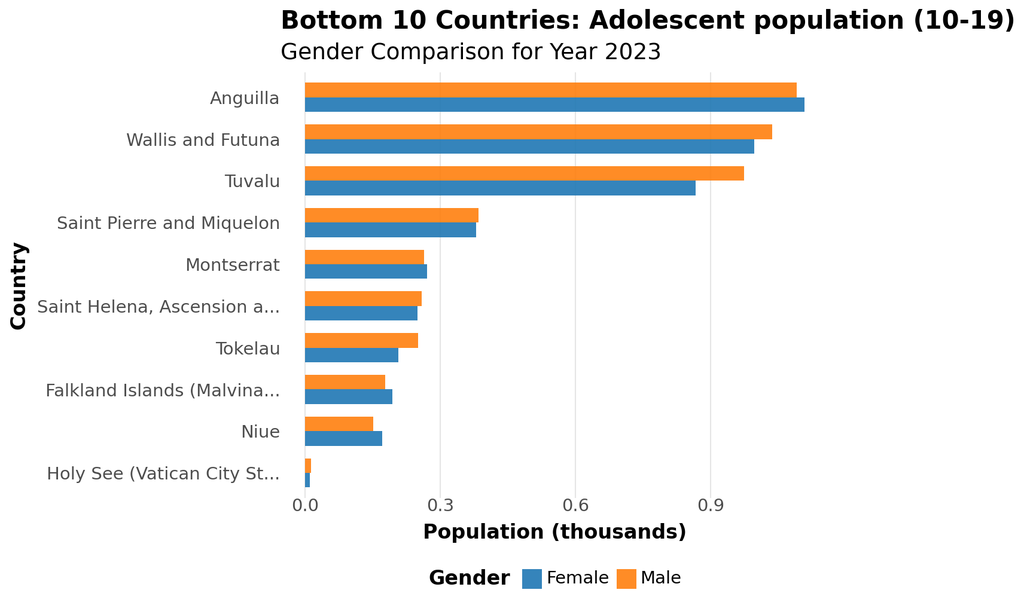

```
### Bottom Countries Gender Insights
Overall male-to-female ratio among bottom countries: 1.03
Highest male-to-female ratio: Holy See (Vatican City State) (1.30)
Lowest male-to-female ratio: Niue (0.88)
```

```python
def create_bottom_bar_chart(indicator, year, bottom_n=10, data=df):
    """Create a bar chart comparing bottom countries for an indicator with improved visibility, breaking down by sex"""
    print(f"\n## Bottom Countries Analysis: {indicator}")

    # Filter data for the given indicator and year
    chart_data = data[(data[indicator_col] == indicator) & (data[year_col] == year)]

    if chart_data.empty:
        print(f"No data found for {indicator} in year {year}")
        return None

    # Filter for Male and Female data
    chart_data = chart_data[chart_data["sex"].isin(['Male', 'Female'])]

    # Get countries with non-zero values to avoid countries with missing data
    valid_countries = chart_data.groupby(country_col)[value_col].sum()
    valid_countries = valid_countries[valid_countries > 0]

    # Get bottom countries by total population
    bottom_country_values = valid_countries.nsmallest(bottom_n).index
    filtered_data = chart_data[chart_data[country_col].isin(bottom_country_values)]

    if filtered_data.empty:
        print(f"No data found for the bottom {bottom_n} countries in {indicator} for {year}")
        return None

    # Create dataframe for plotting
    plot_data = pd.DataFrame({
        'country': filtered_data[country_col],
        'sex': filtered_data["sex"],
        'value': filtered_data[value_col]
    })

    # Sort data by total value per country for better presentation
    country_totals = plot_data.groupby('country')['value'].sum().reset_index()
    country_totals = country_totals.sort_values('value')  # Ascending order for bottom countries
    plot_data['country'] = pd.Categorical(
        plot_data['country'],
        categories=country_totals['country'].tolist(),
        ordered=True
    )
    plot_data = plot_data.sort_values('country')

    # Format country names to ensure they're readable
    plot_data['country_label'] = plot_data['country'].apply(
        lambda x: x[:25] + '...' if len(str(x)) > 25 else x
    )

    # Calculate gender ratio for annotation
    gender_ratios = plot_data.pivot_table(
        index='country',
        columns='sex',
        values='value'
    ).reset_index()

    # Handle division by zero for ratio calculation
    gender_ratios['ratio'] = gender_ratios.apply(
        lambda row: row['Male'] / row['Female'] if row['Female'] > 0 else float('nan'),
        axis=1
    )

    # Build enhanced bar chart with value labels
    bar_chart = (
        ggplot(plot_data, aes(x='country_label', y='value', fill='sex')) +
        geom_bar(stat='identity', alpha=0.9, width=0.7, position='dodge') +
        coord_flip() +
        scale_fill_manual(values=['#1f77b4', '#ff7f0e']) +
        labs(
            title=f"Bottom {bottom_n} Countries: {indicator}",
            subtitle=f"Gender Comparison for Year {year}",
            x="Country",
            y="Population (thousands)",
            fill="Gender"
        ) +
        theme_minimal() +
        theme(
            panel_grid_major_y=element_blank(),
            panel_grid_minor=element_blank(),
            legend_position="bottom",
            legend_title=element_text(face="bold"),
            axis_text_y=element_text(size=14),  # Increase country label font size
            axis_text_x=element_text(size=12)   # Increase x-axis value font size
        )
    )

    # Use the enhanced display function with larger dimensions for better readability
    display_plot(bar_chart, width=1400, height=1000, dpi=150)

    # Calculate and display gender disparity insights
    male_total = plot_data[plot_data['sex'] == 'Male']['value'].sum()
    female_total = plot_data[plot_data['sex'] == 'Female']['value'].sum()
    total_ratio = male_total / female_total if female_total > 0 else 0

    # Display insights about the gender comparison
    print(f"\n### Bottom Countries Gender Insights")
    print(f"Overall male-to-female ratio among bottom countries: {total_ratio:.2f}")

    # Find country with highest gender disparity
    if not gender_ratios.empty and not gender_ratios['ratio'].isna().all():
        valid_ratios = gender_ratios.dropna(subset=['ratio'])
        if not valid_ratios.empty:
            max_disparity = valid_ratios.loc[valid_ratios['ratio'].idxmax()]
            min_disparity = valid_ratios.loc[valid_ratios['ratio'].idxmin()]
            print(f"Highest male-to-female ratio: {max_disparity['country']} ({max_disparity['ratio']:.2f})")
            print(f"Lowest male-to-female ratio: {min_disparity['country']} ({min_disparity['ratio']:.2f})")

# Create bar chart for the bottom countries using the top indicator and latest year
if len(top_indicators) > 0:
    create_bottom_bar_chart(top_indicators[0], latest_year, bottom_n=10)
```

### 📉 Bottom Countries Analysis

This visualization provides valuable insights into countries with the lowest values for our indicator:

- The bottom countries typically have much smaller absolute populations compared to the top countries
- Gender disparities still exist in these nations but may show different patterns
- These countries may represent small nations, those with successful interventions, or those with data collection challenges
- Comparing the bottom and top charts helps place the global distribution in better context

## 📝 Conclusions

Together, these visualizations provide a comprehensive view of global child development trends and patterns.

## 📚 References

1. UNICEF. (2023). The State of the World’s Children. Retrieved from https://www.unicef.org/reports/state-worlds-children
2. United Nations. (2023). Sustainable Development Goals Report. Retrieved from https://unstats.un.org/sdgs/report/2023/